# Binary Multiple Predictors with FL Rodents — Known Locomotion Scores

# Overview

This script is a modified version of `Binary_Multiple_Predictors.Rmd`. The key difference is that this version uses a training dataset that includes known locomotion scores (Loc_bin) for the four focal Florida rodent species:

- Ochrotomys nuttalli → climbing (1)
- Peromyscus gossypinus → climbing (1)
- Peromyscus polionotus → no climbing (0)
- Podomys floridanus → no climbing (0)

Because locomotion is now known for these species, the custom Bernoulli family is not needed — standard bernoulli() is used instead. The imputation submodels for missing skeletal measurements are otherwise identical.

This version is useful for checking whether model predictions for these species are consistent with their known locomotion when treated as training data, i.e. as a validation exercise.

# 1. Setup

```r
# Load dataset with known locomotion scores for the FL species
# (differs from Clean_Data.csv which has NA for these species)
dat <- read_csv(here("Data", "Clean_Data_FL_scores.csv"))

# Species present in dataset (needed to prune the phylogeny)
spp_obs <- dat$Taxon_Upham_style %>% unique()

# Color palette (one color per species, used throughout)
pal <- c('#62361B', '#f48a1a', '#e6ab02', '#66a61e', '#31c1bb',
         '#0d57ff', '#5e1ea6', '#f9581c', '#f384f8')

# Load phylogenetic tree and compute correlation matrix
tr <- ape::read.nexus(here("Data", "MCC_Upham_all_mammals.nex"))
tr <- ape::keep.tip(tr, spp_obs)
A  <- ape::vcv.phylo(tr, corr = TRUE)
```

# 2. Model Specification

Because locomotion is known for all focal species in this dataset, we use the standard bernoulli() family. No custom Stan code is needed.

Predictors are the same as in Binary_Multiple_Predictors.Rmd: - Complete measurements: Fl, Hl, HPI, Uol - Measurements with missing data (imputed): PES, MANUS, Ppl, Ul, OLI, Rl, log_Mass

```r
# Main binary outcome model — standard bernoulli, no custom family needed
bin_mod <- bf(
  Loc_bin ~
    Fl + Hl + HPI + Uol +
    mi(PES) + mi(MANUS) + mi(Ppl) + mi(Ul) +
    mi(OLI) + mi(Rl) + mi(log_Mass) +
    (1 | Genus_species) +
    (1 | gr(Taxon_Upham_style, cov = A))
) + bernoulli()

# Imputation submodels — identical to Binary_Multiple_Predictors.Rmd
PES_mod   <- bf(PES   | mi() ~ Fl + Fdw + Fsw + Tpw + Hl + Hdw + Hpw + Hsw + Uol + Mtl + (1|Genus_species) + (1|gr(Taxon_Upham_style, cov = A))) + gaussian()
MANUS_mod <- bf(MANUS | mi() ~ Fl + Fdw + Fsw + Tpw + Hl + Hdw + Hpw + Hsw + Uol + Mtl + (1|Genus_species) + (1|gr(Taxon_Upham_style, cov = A))) + gaussian()
Ppl_mod   <- bf(Ppl   | mi() ~ Fl + Fdw + Fsw + Tpw + Hl + Hdw + Hpw + Hsw + Uol + Mtl + (1|Genus_species) + (1|gr(Taxon_Upham_style, cov = A))) + gaussian()
Ul_mod    <- bf(Ul    | mi() ~ Fl + Fdw + Fsw + Tpw + Hl + Hdw + Hpw + Hsw + Uol + Mtl + (1|Genus_species) + (1|gr(Taxon_Upham_style, cov = A))) + gaussian()
OLI_mod   <- bf(OLI   | mi() ~ Fl + Fdw + Fsw + Tpw + Hl + Hdw + Hpw + Hsw + Uol + Mtl + (1|Genus_species) + (1|gr(Taxon_Upham_style, cov = A))) + gaussian()
Rl_mod    <- bf(Rl    | mi() ~ Fl + Fdw + Fsw + Tpw + Hl + Hdw + Hpw + Hsw + Uol + Mtl + (1|Genus_species) + (1|gr(Taxon_Upham_style, cov = A))) + gaussian()
mass_mod  <- bf(log_Mass | mi() ~ Fl + Fdw + Fsw + Tpw + Hl + Hdw + Hpw + Hsw + Uol + Mtl + (1|Genus_species) + (1|gr(Taxon_Upham_style, cov = A))) + gaussian()

m_form <- bin_mod + PES_mod + MANUS_mod + Ppl_mod + Ul_mod +
          OLI_mod + Rl_mod + mass_mod + set_rescor(FALSE)

# Priors — identical to Binary_Multiple_Predictors.Rmd
pri <- get_prior(m_form, data = dat, data2 = list(A = A)) %>%
  mutate(prior = case_when(
    class == "b" & coef == ""                       ~ "normal(0, 2)",
    class == "sd" & coef == "" & resp == "Locbin"   ~ "normal(0, 0.3)",
    class == "sd" & coef == "" & resp != "Locbin"   ~ "normal(0, 1)",
    class == "Intercept"                            ~ "normal(0, 2)",
    class == "sigma"                                ~ "normal(0, 0.5)",
    TRUE ~ prior
  ))
```

# 3. Fit and Save Model

```r
multmod <- brm(
  m_form,
  data     = dat,
  data2    = list(A = A),
  prior    = pri,
  cores    = 4,
  seed     = 145,
  refresh  = 0,
  silent   = 2,
  control  = list(max_treedepth = 15)
)

multmod %>% write_rds(here("Data", "B_mod_multi_FL_scores.Rds"))
```

# 4. Prepare Prediction Data

```r
mice <- c("Podomys_floridanus", "Ochrotomys_nuttalli",
          "Peromyscus_gossypinus", "Peromyscus_polionotus")

# These species now have known Loc_bin scores so re_formula = NULL will
# use their fitted species random effects rather than drawing new levels
model_dat <- dat %>%
  filter(Genus_species %in% mice)
```

# 5. Predictions — Multiple Methods

Four prediction approaches are compared to decompose the contributions of the species random effect, phylogenetic random effect, and fixed effects (morphology):

- Full: both species RE and phylogenetic RE included
- Species_RE: species RE only (no phylogenetic covariance)
- Phylo_only: phylogenetic RE only (no species RE)
- Fixed_only: fixed effects (morphology) only — re_formula = NA

Because the FL species are in the training data, the Full predictions will be very confident (the model has direct locomotion information for these species). The Fixed_only predictions are the most informative for understanding what morphology alone is contributing.

```r
# Helper function to generate species-averaged predictions for a given re_formula
get_pred_species <- function(re_form, method_label, allow_new = FALSE) {
  multmod %>%
    add_epred_draws(
      newdata          = model_dat,
      resp             = "Locbin",
      value            = "Prob_of_Climbing",
      re_formula       = re_form,
      allow_new_levels = allow_new
    ) %>%
    as.data.frame() %>%
    group_by(Genus_species, .draw) %>%
    summarise(Prob_of_Climbing = mean(Prob_of_Climbing, na.rm = TRUE),
              .groups = "drop") %>%
    mutate(method = method_label)
}

# Full model — both random effects
pred_full <- get_pred_species(NULL, "Full")

# Species RE only — drops phylogenetic covariance
pred_species_only <- get_pred_species(~(1|Genus_species), "Species_RE")

# Phylogenetic RE only — drops species identity
pred_phylo_only <- get_pred_species(~(1|gr(Taxon_Upham_style, cov = A)), "Phylo_only")

# Fixed effects only — morphology alone, no random effects
pred_fixef <- get_pred_species(NA, "Fixed_only")

# Combine all methods
pred_all_methods <- bind_rows(pred_full, pred_species_only, pred_phylo_only, pred_fixef) %>%
  mutate(method = factor(method, levels = c("Full", "Species_RE", "Phylo_only", "Fixed_only")))
```

# 6. Imputation-Aware Predictions

Because the FL species are now in the training data, brms has posterior imputed values (Ymi_) for any missing skeletal measurements in these specimens. We extract and inject these draw-by-draw to properly propagate imputation uncertainty — same approach as Binary_Multiple_Predictors.Rmd.

WARNING: this section takes ~5 minutes with 8 workers. Skip if just exploring.

```r
focal_rows <- which(dat$Genus_species %in% mice)

ymi_draws <- as_draws_df(multmod) %>%
  select(.draw, starts_with("Ymi_"))

ymi_index_df <- tibble(col = names(ymi_draws)[-1]) %>%
  mutate(
    variable = str_extract(col, "(?<=Ymi_)[A-Za-z]+"),
    row_idx  = as.integer(str_extract(col, "(?<=\\[)\\d+(?=\\])"))
  ) %>%
  filter(row_idx %in% focal_rows) %>%
  left_join(
    dat %>% mutate(row_idx = row_number()) %>% select(row_idx, catalog, Genus_species),
    by = "row_idx"
  )

ymi_long <- ymi_draws %>%
  pivot_longer(-.draw, names_to = "col", values_to = "imputed") %>%
  inner_join(ymi_index_df %>% select(col, variable, row_idx, catalog), by = "col") %>%
  select(.draw, variable, row_idx, catalog, imputed)

mi_vars <- c("PES", "MANUS", "Ppl", "Ul", "OLI", "Rl", "log_Mass")

model_dat_indexed <- model_dat %>%
  mutate(row_idx = which(dat$Genus_species %in% mice))

empty_imp <- tibble(
  row_idx      = integer(),
  PES_imp      = double(), MANUS_imp    = double(), Ppl_imp      = double(),
  Ul_imp       = double(), OLI_imp      = double(), Rl_imp       = double(),
  log_Mass_imp = double()
)
```

```r
tictoc::tic()
plan(multisession, workers = 8)

thin_draws <- seq(1, 4000, by = 4)
chunk_size <- 250
chunks     <- split(thin_draws, ceiling(seq_along(thin_draws) / chunk_size))

for (chunk_i in seq_along(chunks)) {
  chunk_draws <- chunks[[chunk_i]]
  message(glue("Starting chunk {chunk_i} of {length(chunks)}"))

  chunk_results <- future_map(chunk_draws, ~{
    d <- .x

    imputed_d <- ymi_long %>%
      filter(.draw == d) %>%
      select(row_idx, variable, imputed) %>%
      pivot_wider(names_from = variable, values_from = imputed) %>%
      bind_rows(empty_imp)

    newdata_d <- model_dat_indexed %>%
      left_join(imputed_d, by = "row_idx", suffix = c("", "_imp")) %>%
      mutate(
        PES      = coalesce(PES,      PES_imp),
        MANUS    = coalesce(MANUS,    MANUS_imp),
        Ppl      = coalesce(Ppl,      Ppl_imp),
        Ul       = coalesce(Ul,       Ul_imp),
        OLI      = coalesce(OLI,      OLI_imp),
        Rl       = coalesce(Rl,       Rl_imp),
        log_Mass = coalesce(log_Mass, log_Mass_imp)
      ) %>%
      select(-ends_with("_imp"), -row_idx)

    multmod %>%
      add_epred_draws(
        newdata    = newdata_d,
        resp       = "Locbin",
        value      = "Prob_of_Climbing",
        re_formula = NULL,
        draw_ids   = d
      ) %>%
      as.data.frame() %>%
      select(Genus_species, catalog, Prob_of_Climbing) %>%
      mutate(.draw = d)

  }, .options = furrr_options(
    seed     = TRUE,
    globals  = c("ymi_long", "model_dat_indexed", "empty_imp", "multmod"),
    packages = c("dplyr", "tidyr", "brms", "tidybayes")
  ))

  saveRDS(chunk_results, here("Data", glue("pred_chunk_FL_scores_{chunk_i}.rds")))
  message(glue("Chunk {chunk_i} saved"))
}
```

# 7. Plots

## 7a. Method comparison — species-level predictions

Four panels showing how predictions change as random effects are added. The Full model will be tightly near 0/1 since locomotion is known for these species. Fixed_only is the most informative for what morphology alone predicts.

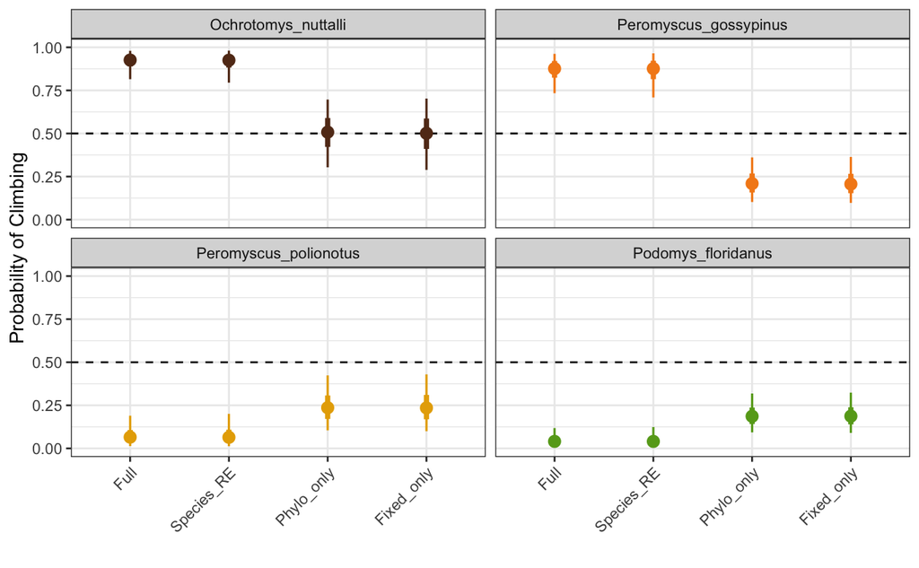

```r
pred_all_methods %>%
  ggplot(aes(y = Prob_of_Climbing, x = method, color = Genus_species)) +
  geom_hline(yintercept = 0.5, linetype = 2, linewidth = 0.5) +
  stat_pointinterval(
    .width   = c(0.5, 0.89),
    position = position_dodge(width = 0.4)
  ) +
  ylim(0, 1) +
  facet_wrap(~Genus_species) +
  labs(x = "", y = "Probability of Climbing") +
  scale_color_manual(values = pal) +
  theme_bw() +
  theme(
    axis.text.x  = element_text(angle = 45, hjust = 1),
    legend.position = "none"
  )
```

## 7b. Individual specimen predictions (full model, imputation-aware)

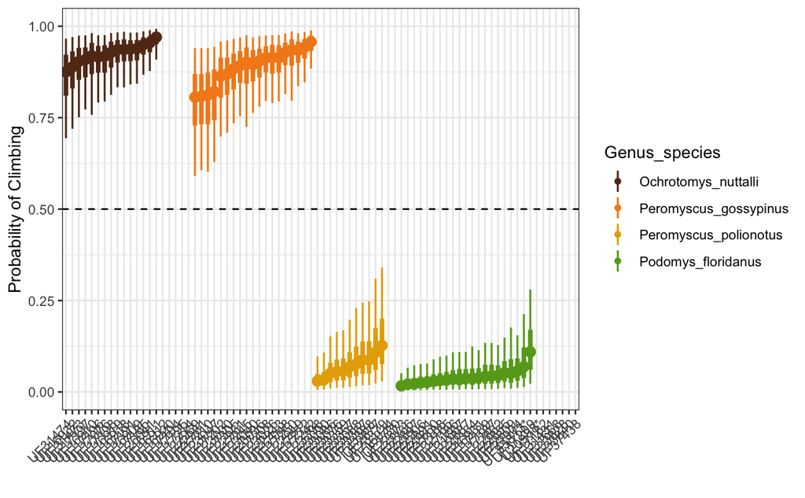

```r
pred_proper %>%
  group_by(catalog, Genus_species) %>%
  mutate(mean_prob = mean(Prob_of_Climbing, na.rm = TRUE)) %>%
  ungroup() %>%
  mutate(
    catalog = reorder(catalog, mean_prob),
    catalog = reorder(catalog, as.numeric(factor(Genus_species)))
  ) %>%
  ggplot(aes(y = Prob_of_Climbing, x = catalog, color = Genus_species)) +
  geom_hline(yintercept = 0.5, linetype = 2, linewidth = 0.5) +
  stat_pointinterval(.width = c(0.5, 0.89)) +
  ylim(0, 1) +
  labs(x = "", y = "Probability of Climbing") +
  scale_color_manual(values = pal) +
  theme_bw() +
  theme(axis.text.x = element_text(angle = 45, hjust = 1))
```

## 7c. Species-level predictions (imputation-aware, averaged over individuals)

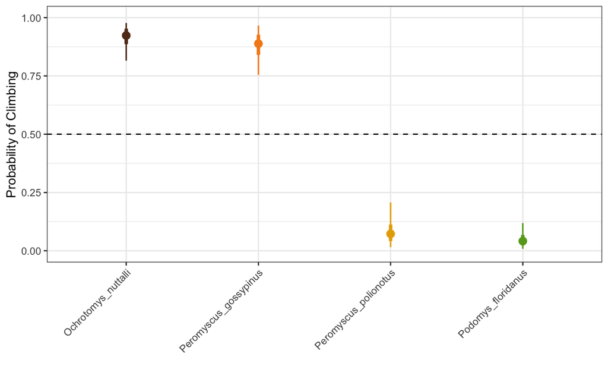

```r
pred_proper_species <- pred_proper %>%
  group_by(Genus_species, .draw) %>%
  summarise(Prob_of_Climbing = mean(Prob_of_Climbing, na.rm = TRUE), .groups = "drop")

pred_proper_species %>%
  ggplot(aes(y = Prob_of_Climbing, x = Genus_species, color = Genus_species)) +
  geom_hline(yintercept = 0.5, linetype = 2, linewidth = 0.5) +
  stat_pointinterval(.width = c(0.5, 0.89)) +
  ylim(0, 1) +
  labs(x = "", y = "Probability of Climbing") +
  scale_color_manual(values = pal) +
  theme_bw() +
  theme(
    axis.text.x  = element_text(angle = 45, hjust = 1),
    legend.position = "none"
  )
```

## 7d. Pairwise contrasts between species

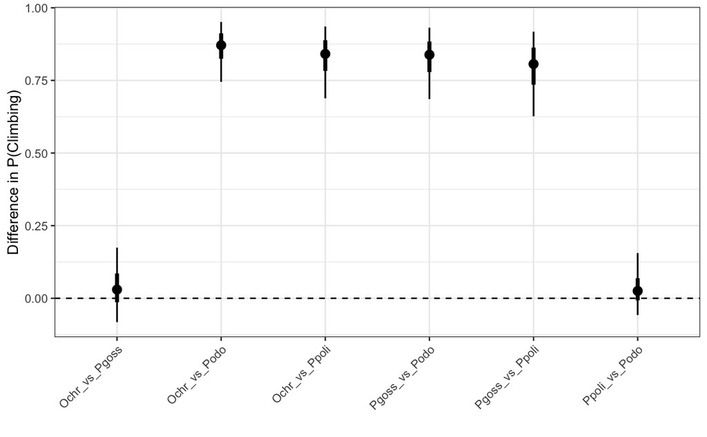

```r
pred_proper_species %>%
  pivot_wider(names_from = Genus_species, values_from = Prob_of_Climbing) %>%
  mutate(
    Ochr_vs_Pgoss  = Ochrotomys_nuttalli - Peromyscus_gossypinus,
    Ochr_vs_Ppoli  = Ochrotomys_nuttalli - Peromyscus_polionotus,
    Ochr_vs_Podo   = Ochrotomys_nuttalli - Podomys_floridanus,
    Pgoss_vs_Ppoli = Peromyscus_gossypinus - Peromyscus_polionotus,
    Pgoss_vs_Podo  = Peromyscus_gossypinus - Podomys_floridanus,
    Ppoli_vs_Podo  = Peromyscus_polionotus - Podomys_floridanus
  ) %>%
  select(.draw, Ochr_vs_Pgoss:Ppoli_vs_Podo) %>%
  pivot_longer(-.draw, names_to = "contrast", values_to = "difference") %>%
  ggplot(aes(y = difference, x = contrast)) +
  geom_hline(yintercept = 0, linetype = 2, linewidth = 0.5) +
  stat_pointinterval(.width = c(0.5, 0.89)) +
  labs(x = "", y = "Difference in P(Climbing)") +
  theme_bw() +
  theme(axis.text.x = element_text(angle = 45, hjust = 1))

ggsave(here("Plots", "Bin_Multiple_Reg_Plots_FL_scores.pdf"), height = 8, width = 13)
```